# P3-CP3

# Sobre os dados

Nessa atividade estamos utilizando um dataset sobre filmes onde utilizaremos dados como: a media da idade dos atores do filme, o ano de lançamento, a media da quantidade de palavras faladas pelos atores e a renda de cada filme.

# Contextualizacao

Na atividade anterior trabalhamos com normalizacao dos dados, o algoritmo K means que objetiva buscar clusters de grupos, mas o resultado foram muitas variaveis e nessa atividade veremos como diminuir a dimensionalidade através de componentes principais, facilitando a leitura dos dados.

# Resultados

```r
pr.out <- prcomp(select(filme_agrupado2.scaled, -title), scale=TRUE)
tidy(pr.out, "variables") %>%
    filter(PC <= 2) %>%
    spread(column, value)
```

```
##   PC ano_lancamento media_idade media_palavras      renda
## 1  1      0.6358729  0.07456969      0.4157906 -0.6459282
## 2  2     -0.2532801 -0.91983557      0.1453630 -0.2619567
```

## Explicacao dos pcs

Calculando 2 dos componentes principais, vemos que o primeiro tem uma grande conformidade com as variaveis media de palavras e principalmente ano de lancamento, a variavel renda tambem varia com PC1, mas são inversamente proporcional. Enquanto que a variacao do pc1 nao interfere tanto na media de idade dos atores dos filmes.

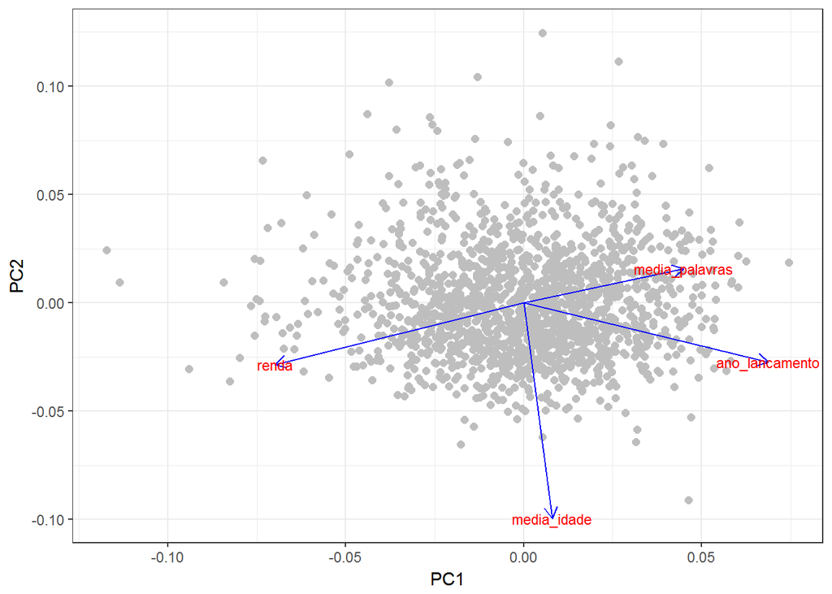

```r
autoplot(pr.out, data = filme_agrupado2.scaled, size = 2,
         colour = "grey",
         loadings = TRUE, loadings.colour = 'blue',
         loadings.label = TRUE,
         loadings.label.size = 3)
```

## Explicando o grafico anterior

Acima vemos o grafico que poe PC1 e PC2 num plano cartesiano e explica melhor o que foi dito sobre as variaveis e suas variacoes de acordo com os componentes principais.

Em PC1 as variaveis mais influenciadas sao media de palavras, ano de lancamento e a renda dos filmes, a media de idade dos atores interfere minimamente nessa variavel. Em PC2 media idade é o que mais varia com esse componente principal, as outras 3 variaveis variam pouco com PC2.

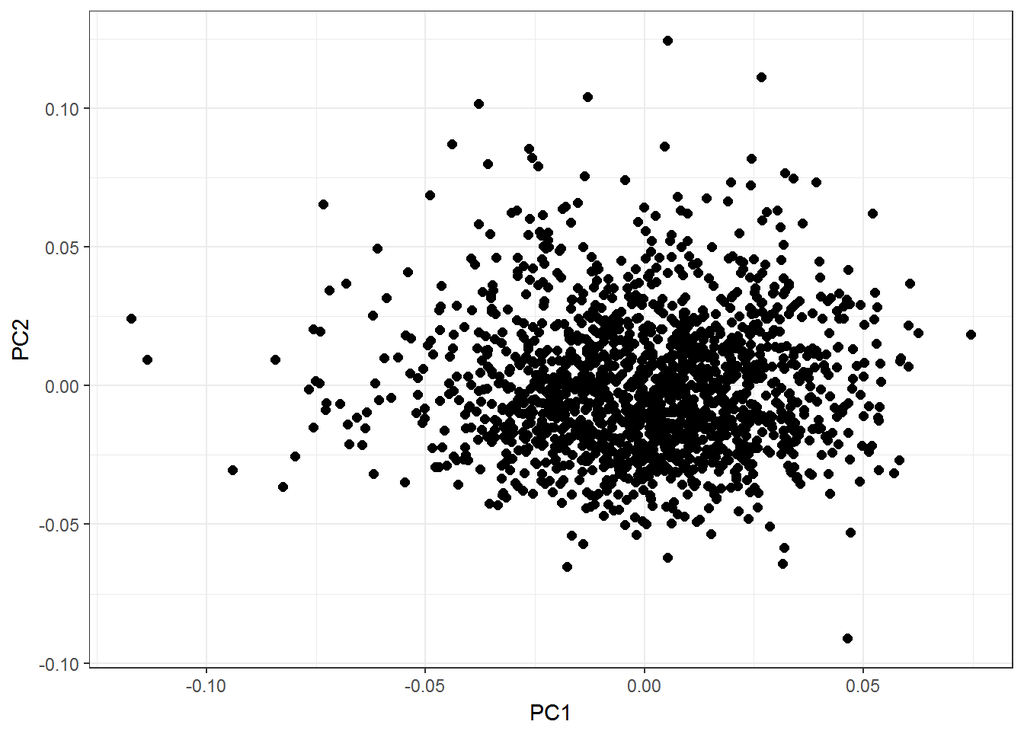

```r
autoplot(pr.out, data = filme_agrupado2.scaled, size = 2,
         loadings = FALSE)
```